# VERİ

###### Veri setinin işlenmesi

```python
import numpy as np
import pandas as pd
```

```python
# Doğuş Datathon verileri
category = pd.read_csv('data/category.csv')
cover = pd.read_csv("data/cover.csv")
prices = pd.read_csv("data/prices.csv")
sales = pd.read_csv("data/sales.csv")
submission = pd.read_csv("data/sample_submission.csv")
stores = pd.read_csv("data/stores.csv")
```

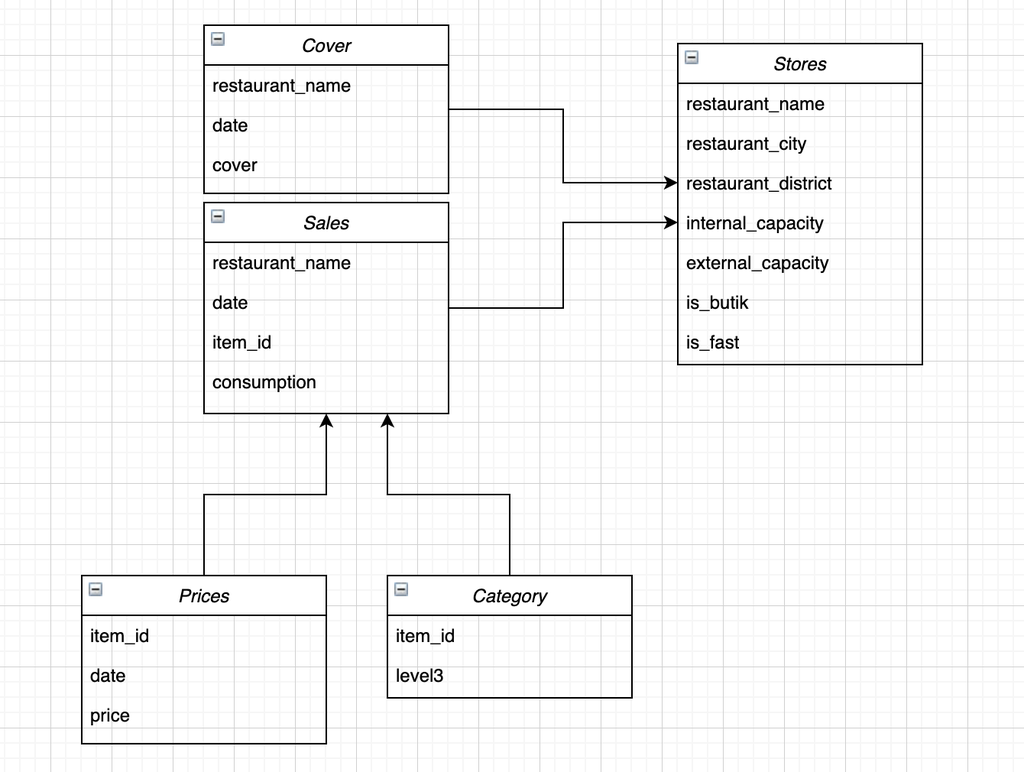

```python
from IPython.display import Image

Image(filename='data/external/er.png', width=400)
```

```python
merged_sales = pd.concat([sales,submission])
merged_sales.info()
```

```
<class 'pandas.core.frame.DataFrame'>
Int64Index: 475519 entries, 0 to 44999
Data columns (total 4 columns):
 #   Column           Non-Null Count   Dtype
---  ------           --------------   -----
 0   restaurant_name  475519 non-null  object
 1   Date             475519 non-null  object
 2   ItemId           475519 non-null  object
 3   CONSUMPTION      475519 non-null  float64
dtypes: float64(1), object(3)
memory usage: 18.1+ MB
```

```python
merged_sales.tail()
```

|  | restaurant_name | Date | ItemId | CONSUMPTION |
| --- | --- | --- | --- | --- |
| 44995 | QUICK05 | 2020-02-29 | SM.RM.00076 | 0.0 |
| 44996 | QUICK05 | 2020-02-29 | SM.RM.00081 | 0.0 |
| 44997 | QUICK05 | 2020-02-29 | SM.RM.00083 | 0.0 |
| 44998 | QUICK05 | 2020-02-29 | SM.RM.00084 | 0.0 |
| 44999 | QUICK05 | 2020-02-29 | SM.RM.00090 | 0.0 |

- Doğuş Teknoloji tarafından paylaşılan Datathon verilerini inceleyip aralarındaki ilişkiyi belirledik, ardından left-join yöntemi ile birleştirerek tek bir set haline getirdik.

### 'Sales' ve 'Cover' verisinin birleştirilmesi

```python
merged_sales.rename(columns={'Date': 'date'}, inplace=True)
```

```python
data = pd.merge(merged_sales, cover, on=['restaurant_name', 'date'], how='left')

data.count()
```

```
restaurant_name    475519
date               475519
ItemId             475519
CONSUMPTION        475519
cover              430519
dtype: int64
```

```python
data.rename(columns={'ItemId': 'ItemID'}, inplace=True)
```

### 'Category' verisinin eklenmesi

```python
data = pd.merge(data, category, on=['ItemID'], how='left')

data.count()
```

```
restaurant_name    475519
date               475519
ItemID             475519
CONSUMPTION        475519
cover              430519
Level3             475519
dtype: int64
```

### 'Stores' verisinin eklenmesi

```python
data = pd.merge(data, stores, on=['restaurant_name'], how='left')

data.count()
```

```
restaurant_name        475519
date                   475519
ItemID                 475519
CONSUMPTION            475519
cover                  430519
Level3                 475519
restaurant_city        475519
restaurant_district    475519
internal_capacity      475519
external_capacity      475519
is_butik               475519
is_fast                475519
dtype: int64
```

### 'Prices' verisinin eklenmesi

- Aynı gün içerisinde aynı ürün için birden çok veri bulunması sebebiyle ortalama değer ile ilerledik.

```python
prices.rename(columns={'ITEMID': 'ItemID'}, inplace=True)
prices.rename(columns={'Date': 'date'}, inplace=True)
```

```python
prices_avg = prices.groupby(['restaurant_name', 'date', 'ItemID']).mean().reset_index()

prices_avg.tail()
```

|  | restaurant_name | date | ItemID | PRICE |
| --- | --- | --- | --- | --- |
| 244652 | QUICK05 | 2019-12-31 | SM.RM.00053 | 32.30 |
| 244653 | QUICK05 | 2019-12-31 | SM.RM.00055 | 32.30 |
| 244654 | QUICK05 | 2019-12-31 | SM.RM.00057 | 32.30 |
| 244655 | QUICK05 | 2019-12-31 | SM.RM.00067 | 33.15 |
| 244656 | QUICK05 | 2019-12-31 | SM.RM.00081 | 51.00 |

```python
data = pd.merge(data, prices_avg, on=['restaurant_name', 'date', 'ItemID'], how='left')

data.count()
```

```
restaurant_name        475519
date                   475519
ItemID                 475519
CONSUMPTION            475519
cover                  430519
Level3                 475519
restaurant_city        475519
restaurant_district    475519
internal_capacity      475519
external_capacity      475519
is_butik               475519
is_fast                475519
PRICE                  161140
dtype: int64
```

- Verileri birleştirme işlemini tamamladıktan sonra aşağıdaki tabloyu elde ettik.

```python
data.tail()
```

|  | restaurant_name | date | ItemID | CONSUMPTION | cover | Level3 | restaurant_city | restaurant_district | internal_capacity | external_capacity | is_butik | is_fast | PRICE |
| --- | --- | --- | --- | --- | --- | --- | --- | --- | --- | --- | --- | --- | --- |
| 475514 | QUICK05 | 2020-02-29 | SM.RM.00076 | 0.0 | NaN | Taze Kuzu Etleri | Istanbul | Sisli | 42 | 88 | 0 | 0 | NaN |
| 475515 | QUICK05 | 2020-02-29 | SM.RM.00081 | 0.0 | NaN | Taze Kuzu Etleri | Istanbul | Sisli | 42 | 88 | 0 | 0 | NaN |
| 475516 | QUICK05 | 2020-02-29 | SM.RM.00083 | 0.0 | NaN | Kırmızı Et - Yarı Mamüller | Istanbul | Sisli | 42 | 88 | 0 | 0 | NaN |
| 475517 | QUICK05 | 2020-02-29 | SM.RM.00084 | 0.0 | NaN | Taze Kuzu Etleri | Istanbul | Sisli | 42 | 88 | 0 | 0 | NaN |
| 475518 | QUICK05 | 2020-02-29 | SM.RM.00090 | 0.0 | NaN | Kırmızı Et - Yarı Mamüller | Istanbul | Sisli | 42 | 88 | 0 | 0 | NaN |

- Mevcut verilere ek olarak, sonuca etki edebileceğini düşündüğümüz farklı verileri araştırarak feature sayımızı arttırdık.

### Restoranların bulunduğu bölgelere ait hava durumu

**Kaynak:** İstanbul Büyükşehir Belediyesi, havadurumu.com.tr

- Hava durumu, iç ve dış mekan kişi kapasitelerine göre restoranların doluluk oranlarını etkileyebilir.

```python
weather = pd.read_csv("data/external/hava_yagis_verisi_new_ysf.csv")

weather.tail()
```

|  | date | Ort_Hava_S | Min_Hava_S | Maks_Hava_S |
| --- | --- | --- | --- | --- |
| 998 | 2020-02-25 | 10.46 | 3.67 | 17.70 |
| 999 | 2020-02-26 | 16.05 | 10.32 | 21.41 |
| 1000 | 2020-02-27 | 15.02 | 8.43 | 20.51 |
| 1001 | 2020-02-28 | 10.96 | 7.93 | 14.89 |
| 1002 | 2020-02-29 | 7.95 | 4.48 | 9.75 |

```python
data = pd.merge(data, weather, on=['date'], how='left')
```

```python
data.info()
```

```
<class 'pandas.core.frame.DataFrame'>
Int64Index: 475519 entries, 0 to 475518
Data columns (total 16 columns):
 #   Column               Non-Null Count   Dtype
---  ------               --------------   -----
 0   restaurant_name      475519 non-null  object
 1   date                 475519 non-null  object
 2   ItemID               475519 non-null  object
 3   CONSUMPTION          475519 non-null  float64
 4   cover                430519 non-null  float64
 5   Level3               475519 non-null  object
 6   restaurant_city      475519 non-null  object
 7   restaurant_district  475519 non-null  object
 8   internal_capacity    475519 non-null  int64
 9   external_capacity    475519 non-null  int64
 10  is_butik             475519 non-null  int64
 11  is_fast              475519 non-null  int64
 12  PRICE                161140 non-null  float64
 13  Ort_Hava_S           475519 non-null  float64
 14  Min_Hava_S           475519 non-null  float64
 15  Maks_Hava_S          475519 non-null  float64
dtypes: float64(6), int64(4), object(6)
memory usage: 61.7+ MB
```

### Özel günler

**Kaynak:** Afyon Kocatepe Üniversitesi

- Özel anlar, tatil zamanları, maaşların yatırıldığı günler vb. zaman dilimleri insanların restoranlarda yemek yeme eğilimlerini etkileyebilir.

```python
holiday = pd.read_csv("data/external/date_related_w_ozelgunler_new.csv")

holiday.tail()
```

|  | date | index_ | date_str | day | month | year | week_day | day_of_year | week_of_year | is_maas | is_weekend | is_weekend_w_cuma | is_ozel_gun |
| --- | --- | --- | --- | --- | --- | --- | --- | --- | --- | --- | --- | --- | --- |
| 998 | 2020-02-25 | 999 | 2020-02-25 | 25 | 2 | 2020 | 2 | 56 | 9 | 0 | 0 | 0 | 0 |
| 999 | 2020-02-26 | 1000 | 2020-02-26 | 26 | 2 | 2020 | 3 | 57 | 9 | 0 | 0 | 0 | 0 |
| 1000 | 2020-02-27 | 1001 | 2020-02-27 | 27 | 2 | 2020 | 4 | 58 | 9 | 0 | 0 | 0 | 0 |
| 1001 | 2020-02-28 | 1002 | 2020-02-28 | 28 | 2 | 2020 | 5 | 59 | 9 | 0 | 0 | 1 | 0 |
| 1002 | 2020-02-29 | 1003 | 2020-02-29 | 29 | 2 | 2020 | 6 | 60 | 9 | 0 | 1 | 1 | 0 |

```python
holiday.drop("date", axis=1, inplace=True)
holiday.rename(columns={'date_str': 'date'}, inplace=True)
```

```python
data = pd.merge(data, holiday, on=['date'], how='left')
```

```python
data.info()
```

```
<class 'pandas.core.frame.DataFrame'>
Int64Index: 475519 entries, 0 to 475518
Data columns (total 27 columns):
 #   Column               Non-Null Count   Dtype
---  ------               --------------   -----
 0   restaurant_name      475519 non-null  object
 1   date                 475519 non-null  object
 2   ItemID               475519 non-null  object
 3   CONSUMPTION          475519 non-null  float64
 4   cover                430519 non-null  float64
 5   Level3               475519 non-null  object
 6   restaurant_city      475519 non-null  object
 7   restaurant_district  475519 non-null  object
 8   internal_capacity    475519 non-null  int64
 9   external_capacity    475519 non-null  int64
```

[output cut: 19 more lines]

### Volatilite endeksi

**Kaynak:** Yahoo Finance

- Volatilite endeksi, piyasanın 30 günlük ileriye dönük dalgalanma beklentisini temsil eden gerçek zamanlı bir endeks olduğu için müşteri hareketlerini ve tüketim oranlarını etkileyebilir.

```python
vix = pd.read_csv("data/external/vix_bfilled.csv")

vix.head()
```

|  | Date | Close |
| --- | --- | --- |
| 0 | 2017-01-03 | 12.85 |
| 1 | 2017-01-04 | 11.85 |
| 2 | 2017-01-05 | 11.67 |
| 3 | 2017-01-06 | 11.32 |
| 4 | 2017-01-07 | 11.56 |

```python
vix.rename(columns={'Date': 'date', 'Close': 'vix'}, inplace=True)
```

```python
data = pd.merge(data, vix, on=['date'], how='left')
```

```python
data.info()
```

```
<class 'pandas.core.frame.DataFrame'>
Int64Index: 475519 entries, 0 to 475518
Data columns (total 28 columns):
 #   Column               Non-Null Count   Dtype
---  ------               --------------   -----
 0   restaurant_name      475519 non-null  object
 1   date                 475519 non-null  object
 2   ItemID               475519 non-null  object
 3   CONSUMPTION          475519 non-null  float64
 4   cover                430519 non-null  float64
 5   Level3               475519 non-null  object
 6   restaurant_city      475519 non-null  object
 7   restaurant_district  475519 non-null  object
 8   internal_capacity    475519 non-null  int64
 9   external_capacity    475519 non-null  int64
```

[output cut: 20 more lines]

### Dolar kuru

**Kaynak:** investing.com

- Döviz oranlarındaki değişimler menüdeki ürün fiyatları ve insanların alım gücü ile olan ilişkisi sebebiyle restoranların müşteri sayısını etkileyebilir.

```python
usd = pd.read_csv("data/external/USD_TRY.csv")
fab_29 = {'Tarih':'29.02.2020', 'Şimdi': '6,2427'}
usd = usd.append(fab_29, ignore_index=True)
```

```python
usd.tail()
```

|  | Tarih | Şimdi | Açılış | Yüksek | Düşük | Fark % |
| --- | --- | --- | --- | --- | --- | --- |
| 820 | 06.01.2017 | 3,6445 | 3,5915 | 3,6498 | 3,5915 | 1,44% |
| 821 | 05.01.2017 | 3,5927 | 3,5720 | 3,6400 | 3,5549 | 0,60% |
| 822 | 04.01.2017 | 3,5713 | 3,5939 | 3,5942 | 3,5670 | -0,64% |
| 823 | 03.01.2017 | 3,5943 | 3,5450 | 3,6052 | 3,5332 | 1,40% |
| 824 | 29.02.2020 | 6,2427 | NaN | NaN | NaN | NaN |

```python
usd.drop(["Açılış", "Yüksek", 'Düşük', 'Fark %'], axis=1, inplace=True)
usd.rename(columns={'Tarih': 'date', 'Şimdi': 'usd'}, inplace=True)
```

```python
usd["tarih"] = pd.to_datetime(usd["date"], format='%d.%m.%Y')
usd.set_index('tarih', inplace=True)
usd = usd.resample('D').bfill().reset_index()
```

```python
usd.tail()
```

|  | tarih | date | usd |
| --- | --- | --- | --- |
| 1148 | 2020-02-25 | 25.02.2020 | 6,1441 |
| 1149 | 2020-02-26 | 26.02.2020 | 6,1590 |
| 1150 | 2020-02-27 | 27.02.2020 | 6,2078 |
| 1151 | 2020-02-28 | 28.02.2020 | 6,2427 |
| 1152 | 2020-02-29 | 29.02.2020 | 6,2427 |

```python
usd.rename(columns={'date': 'date_old'}, inplace=True)
usd["date"] = pd.to_datetime(usd["tarih"], format='%Y-%m-%d').dt.strftime('%Y-%m-%d')
usd.drop(["tarih", "date_old"], axis=1, inplace=True)
```

```python
usd.tail()
```

|  | usd | date |
| --- | --- | --- |
| 1148 | 6,1441 | 2020-02-25 |
| 1149 | 6,1590 | 2020-02-26 |
| 1150 | 6,2078 | 2020-02-27 |
| 1151 | 6,2427 | 2020-02-28 |
| 1152 | 6,2427 | 2020-02-29 |

```python
data = pd.merge(data, usd, on=['date'], how='left')
```

```python
data.info()
```

```
<class 'pandas.core.frame.DataFrame'>
Int64Index: 475519 entries, 0 to 475518
Data columns (total 29 columns):
 #   Column               Non-Null Count   Dtype
---  ------               --------------   -----
 0   restaurant_name      475519 non-null  object
 1   date                 475519 non-null  object
 2   ItemID               475519 non-null  object
 3   CONSUMPTION          475519 non-null  float64
 4   cover                430519 non-null  float64
 5   Level3               475519 non-null  object
 6   restaurant_city      475519 non-null  object
 7   restaurant_district  475519 non-null  object
 8   internal_capacity    475519 non-null  int64
 9   external_capacity    475519 non-null  int64
```

[output cut: 21 more lines]

### Trafik yoğunluğu

**Kaynak:** İstanbul Büyükşehir Belediyesi

- Trafik yoğunluğu müşterilerin ulaşımını ilgilendirmesi dolayısıyla restoranlara gelen müşteri sayısını etkileyebilir.

```python
traffic = pd.read_csv("data/external/traffic_index_daily_clean.csv")

traffic.head()
```

|  | Unnamed: 0 | TrafficIndex | Date |
| --- | --- | --- | --- |
| 0 | 0 | 7 | 2020-09-11 |
| 1 | 1 | 36 | 2020-09-10 |
| 2 | 2 | 29 | 2020-09-09 |
| 3 | 3 | 29 | 2020-09-08 |
| 4 | 4 | 28 | 2020-09-07 |

```python
traffic.rename(columns={'Date': 'date', 'TrafficIndex': 'traffic'}, inplace=True)
traffic.drop(["Unnamed: 0"], axis=1, inplace=True)
```

```python
data = pd.merge(data, traffic, on=['date'], how='left')
```

```python
data.tail()
```

|  | restaurant_name | date | ItemID | CONSUMPTION | cover | Level3 | restaurant_city | restaurant_district | internal_capacity | external_capacity | ... | week_day | day_of_year | week_of_year | is_maas | is_weekend | is_weekend_w_cuma | is_ozel_gun | vix | usd | traffic |
| --- | --- | --- | --- | --- | --- | --- | --- | --- | --- | --- | --- | --- | --- | --- | --- | --- | --- | --- | --- | --- | --- |
| 475514 | QUICK05 | 2020-02-29 | SM.RM.00076 | 0.0 | NaN | Taze Kuzu Etleri | Istanbul | Sisli | 42 | 88 | ... | 6 | 60 | 9 | 0 | 1 | 1 | 0 | NaN | 6,2427 | 34.0 |
| 475515 | QUICK05 | 2020-02-29 | SM.RM.00081 | 0.0 | NaN | Taze Kuzu Etleri | Istanbul | Sisli | 42 | 88 | ... | 6 | 60 | 9 | 0 | 1 | 1 | 0 | NaN | 6,2427 | 34.0 |
| 475516 | QUICK05 | 2020-02-29 | SM.RM.00083 | 0.0 | NaN | Kırmızı Et - Yarı Mamüller | Istanbul | Sisli | 42 | 88 | ... | 6 | 60 | 9 | 0 | 1 | 1 | 0 | NaN | 6,2427 | 34.0 |
| 475517 | QUICK05 | 2020-02-29 | SM.RM.00084 | 0.0 | NaN | Taze Kuzu Etleri | Istanbul | Sisli | 42 | 88 | ... | 6 | 60 | 9 | 0 | 1 | 1 | 0 | NaN | 6,2427 | 34.0 |
| 475518 | QUICK05 | 2020-02-29 | SM.RM.00090 | 0.0 | NaN | Kırmızı Et - Yarı Mamüller | Istanbul | Sisli | 42 | 88 | ... | 6 | 60 | 9 | 0 | 1 | 1 | 0 | NaN | 6,2427 | 34.0 |

5 rows × 30 columns

- Yeni feature'ların eklenmesini tamamladıktan sonra aşağıdaki tabloyu elde ettik.

```python
data.head()
```

|  | restaurant_name | date | ItemID | CONSUMPTION | cover | Level3 | restaurant_city | restaurant_district | internal_capacity | external_capacity | ... | week_day | day_of_year | week_of_year | is_maas | is_weekend | is_weekend_w_cuma | is_ozel_gun | vix | usd | traffic |
| --- | --- | --- | --- | --- | --- | --- | --- | --- | --- | --- | --- | --- | --- | --- | --- | --- | --- | --- | --- | --- | --- |
| 0 | BUT01 | 2017-06-02 | SM.AL.00644 | 1.4 | 372.0 | Beyaz Şaraplar Yerli | Istanbul | Besiktas | 150 | 80 | ... | 5 | 153 | 22 | 1 | 0 | 1 | 0 | 9.75 | 3,5098 | 25.0 |
| 1 | BUT01 | 2017-06-02 | SM.AL.00646 | 1.6 | 372.0 | Beyaz Şaraplar Yerli | Istanbul | Besiktas | 150 | 80 | ... | 5 | 153 | 22 | 1 | 0 | 1 | 0 | 9.75 | 3,5098 | 25.0 |
| 2 | BUT01 | 2017-06-02 | SM.AL.01538 | 1.4 | 372.0 | Kırmızı Şaraplar Yerli | Istanbul | Besiktas | 150 | 80 | ... | 5 | 153 | 22 | 1 | 0 | 1 | 0 | 9.75 | 3,5098 | 25.0 |
| 3 | BUT01 | 2017-06-02 | SM.FO.00005 | 4.6 | 372.0 | Dondurulmuş Diğer Deniz Ürünleri | Istanbul | Besiktas | 150 | 80 | ... | 5 | 153 | 22 | 1 | 0 | 1 | 0 | 9.75 | 3,5098 | 25.0 |
| 4 | BUT01 | 2017-06-02 | SM.FO.00015 | 36.0 | 372.0 | Egzotik Meyveler | Istanbul | Besiktas | 150 | 80 | ... | 5 | 153 | 22 | 1 | 0 | 1 | 0 | 9.75 | 3,5098 | 25.0 |

5 rows × 30 columns

```python
data.info()
```

```
<class 'pandas.core.frame.DataFrame'>
Int64Index: 475519 entries, 0 to 475518
Data columns (total 30 columns):
 #   Column               Non-Null Count   Dtype
---  ------               --------------   -----
 0   restaurant_name      475519 non-null  object
 1   date                 475519 non-null  object
 2   ItemID               475519 non-null  object
 3   CONSUMPTION          475519 non-null  float64
 4   cover                430519 non-null  float64
 5   Level3               475519 non-null  object
 6   restaurant_city      475519 non-null  object
 7   restaurant_district  475519 non-null  object
 8   internal_capacity    475519 non-null  int64
 9   external_capacity    475519 non-null  int64
```

[output cut: 22 more lines]

```python
data['cover'] = data['cover'].fillna(0)
data['PRICE'] = data['PRICE'].fillna(0)
```

```python
data.info()
```

```
<class 'pandas.core.frame.DataFrame'>
Int64Index: 475519 entries, 0 to 475518
Data columns (total 30 columns):
 #   Column               Non-Null Count   Dtype
---  ------               --------------   -----
 0   restaurant_name      475519 non-null  object
 1   date                 475519 non-null  object
 2   ItemID               475519 non-null  object
 3   CONSUMPTION          475519 non-null  float64
 4   cover                475519 non-null  float64
 5   Level3               475519 non-null  object
 6   restaurant_city      475519 non-null  object
 7   restaurant_district  475519 non-null  object
 8   internal_capacity    475519 non-null  int64
 9   external_capacity    475519 non-null  int64
```

[output cut: 22 more lines]

### Verinin hazırlanması

- Modeli yanıltabileceğini düşündüğümüz aykırı değerleri (outlier) eledik.

```python
import seaborn as sns
import matplotlib.pyplot as plt

%matplotlib inline
```

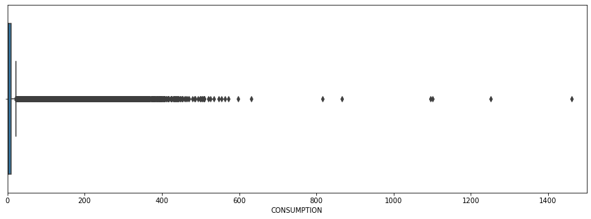

```python
plt.figure(1, figsize=(15, 5))

plt.xlim(0, 1500)
sns.boxplot(x=data.CONSUMPTION)

plt.show()
```

```python
data = data[data["CONSUMPTION"] < 600]
```

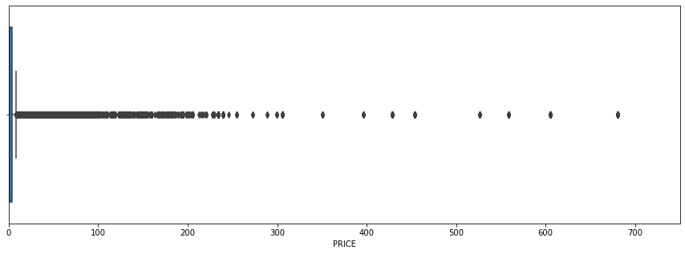

```python
plt.figure(2, figsize=(15, 5))

plt.xlim(0, 750)
sns.boxplot(x=data.PRICE)

plt.show()
```

```python
data = data[data["PRICE"] < 330]
```

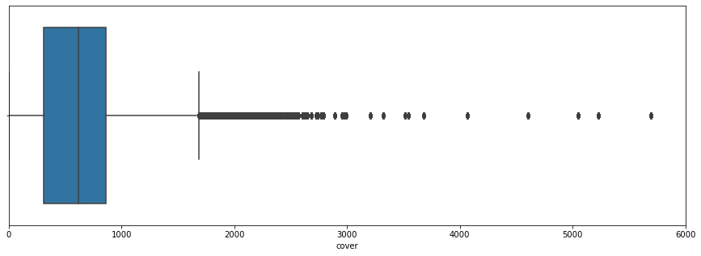

```python
plt.figure(3, figsize=(15, 5))

plt.xlim(0, 6000)
sns.boxplot(x=data.cover)

plt.show()
```

```python
data = data[data["cover"] < 4000]
```

```python
data.info()
```

```
<class 'pandas.core.frame.DataFrame'>
Int64Index: 475137 entries, 0 to 475518
Data columns (total 30 columns):
 #   Column               Non-Null Count   Dtype
---  ------               --------------   -----
 0   restaurant_name      475137 non-null  object
 1   date                 475137 non-null  object
 2   ItemID               475137 non-null  object
 3   CONSUMPTION          475137 non-null  float64
 4   cover                475137 non-null  float64
 5   Level3               475137 non-null  object
 6   restaurant_city      475137 non-null  object
 7   restaurant_district  475137 non-null  object
 8   internal_capacity    475137 non-null  int64
 9   external_capacity    475137 non-null  int64
```

[output cut: 22 more lines]

- Yeni feature'ların türetilmesi, null değerlerin doldurulması vb. ön hazırlık işlemlerini yaparak veriyi kullanıma hazır hale getirdik.

```python
data[['item_id_1', 'item_id_2', 'item_id_3']] = data.ItemID.str.split(".", expand=True)
```

```python
data['item_id_2'].unique()
```

```
array(['AL', 'FO', 'NA', 'BE', 'RM'], dtype=object)
```

```python
data['item_id_2'] = data['item_id_2'].astype(str)
data['item_id_3'] = data['item_id_3'].astype(str)

data['item_id_2'] = data['item_id_2'].str.replace('NA', 'NA2')
```

```python
data.rename(columns={'PRICE': 'price', 'CONSUMPTION': 'consumption',
                     'Ort_Hava_S': 'hava_ort', 'Min_Hava_S': 'hava_min', 'Maks_Hava_S': 'hava_maks'}, inplace=True)
```

```python
data['price'] = data['price'].replace(0, np.nan)
data['price'] = data.groupby("restaurant_name").transform(lambda x: x.fillna(x.mean()))['price']
```

```python
data['traffic'].fillna(data['traffic'].mean(), inplace=True)
data['vix'].fillna(data['vix'].mean(), inplace=True)
```

```python
data.info()
```

```
<class 'pandas.core.frame.DataFrame'>
Int64Index: 475137 entries, 0 to 475518
Data columns (total 33 columns):
 #   Column               Non-Null Count   Dtype
---  ------               --------------   -----
 0   restaurant_name      475137 non-null  object
 1   date                 475137 non-null  object
 2   ItemID               475137 non-null  object
 3   consumption          475137 non-null  float64
 4   cover                475137 non-null  float64
 5   Level3               475137 non-null  object
 6   restaurant_city      475137 non-null  object
 7   restaurant_district  475137 non-null  object
 8   internal_capacity    475137 non-null  int64
 9   external_capacity    475137 non-null  int64
```

[output cut: 25 more lines]

```python
data["usd"] = data.usd.apply(lambda x: x.replace(',', '.'))
data["usd"] = data.usd.astype(float)
```

```python
data.info()
```

```
<class 'pandas.core.frame.DataFrame'>
Int64Index: 475137 entries, 0 to 475518
Data columns (total 33 columns):
 #   Column               Non-Null Count   Dtype
---  ------               --------------   -----
 0   restaurant_name      475137 non-null  object
 1   date                 475137 non-null  object
 2   ItemID               475137 non-null  object
 3   consumption          475137 non-null  float64
 4   cover                475137 non-null  float64
 5   Level3               475137 non-null  object
 6   restaurant_city      475137 non-null  object
 7   restaurant_district  475137 non-null  object
 8   internal_capacity    475137 non-null  int64
 9   external_capacity    475137 non-null  int64
```

[output cut: 25 more lines]

```python
data.tail()
```

|  | restaurant_name | date | ItemID | consumption | cover | Level3 | restaurant_city | restaurant_district | internal_capacity | external_capacity | ... | is_maas | is_weekend | is_weekend_w_cuma | is_ozel_gun | vix | usd | traffic | item_id_1 | item_id_2 | item_id_3 |
| --- | --- | --- | --- | --- | --- | --- | --- | --- | --- | --- | --- | --- | --- | --- | --- | --- | --- | --- | --- | --- | --- |
| 475514 | QUICK05 | 2020-02-29 | SM.RM.00076 | 0.0 | 0.0 | Taze Kuzu Etleri | Istanbul | Sisli | 42 | 88 | ... | 0 | 1 | 1 | 0 | 15.063035 | 6.2427 | 34.0 | SM | RM | 00076 |
| 475515 | QUICK05 | 2020-02-29 | SM.RM.00081 | 0.0 | 0.0 | Taze Kuzu Etleri | Istanbul | Sisli | 42 | 88 | ... | 0 | 1 | 1 | 0 | 15.063035 | 6.2427 | 34.0 | SM | RM | 00081 |
| 475516 | QUICK05 | 2020-02-29 | SM.RM.00083 | 0.0 | 0.0 | Kırmızı Et - Yarı Mamüller | Istanbul | Sisli | 42 | 88 | ... | 0 | 1 | 1 | 0 | 15.063035 | 6.2427 | 34.0 | SM | RM | 00083 |
| 475517 | QUICK05 | 2020-02-29 | SM.RM.00084 | 0.0 | 0.0 | Taze Kuzu Etleri | Istanbul | Sisli | 42 | 88 | ... | 0 | 1 | 1 | 0 | 15.063035 | 6.2427 | 34.0 | SM | RM | 00084 |
| 475518 | QUICK05 | 2020-02-29 | SM.RM.00090 | 0.0 | 0.0 | Kırmızı Et - Yarı Mamüller | Istanbul | Sisli | 42 | 88 | ... | 0 | 1 | 1 | 0 | 15.063035 | 6.2427 | 34.0 | SM | RM | 00090 |

5 rows × 33 columns

```python
data.to_csv("data/dream_merged.csv", header=True, index=False)
```

**Test:**

```python
df = pd.read_csv('data/dream_merged.csv')

df.info()
```

```
<class 'pandas.core.frame.DataFrame'>
RangeIndex: 475137 entries, 0 to 475136
Data columns (total 33 columns):
 #   Column               Non-Null Count   Dtype
---  ------               --------------   -----
 0   restaurant_name      475137 non-null  object
 1   date                 475137 non-null  object
 2   ItemID               475137 non-null  object
 3   consumption          475137 non-null  float64
 4   cover                475137 non-null  float64
 5   Level3               475137 non-null  object
 6   restaurant_city      475137 non-null  object
 7   restaurant_district  475137 non-null  object
 8   internal_capacity    475137 non-null  int64
 9   external_capacity    475137 non-null  int64
```

[output cut: 25 more lines]